# 5_Post Review

Simon

2024-01-09

# Model with linear quadratic costs

## I. Recover W

### C. Attempt to recover W1 and W2:

Notice that we operate under the condition that the marginal cost equals the average cost to find $W$. Now, we are trying to find a linear quadratic function in effort :
$$W_1 + 2W_2 E_{hist} = AC$$

Given the lack of accurate data, we need to run a variety of analysis such that $W_1>0$, $W_2>0$ and $W_1 - AC + 2W_2 E_{Hist} = 0$, eg $W_2 = \frac{AC - W1}{2E_{Hist}}$.

| params | value | concept | units |
| --- | --- | --- | --- |
| alpha | 1625836.98 | Demand model : intercept | USD |
| beta | 1563.75 | Demand model : coefficient | USD/metric ton of biomass |
| r | 0.20 | Intrinsic growth rate | unitless |
| k | 20226.00 | Carrying capacity (in metric tons) | % of biomass/vessel trip |
| sigma | 0.00 | Catchability | metric tons of biomass |
| W_mid | 2.18 | Parameter cost (MC = Avg) at historical value - middle | USD |
| W_low | 1.32 | Parameter cost (MC = Avg) at historical value - low | USD |
| W_high | 3.75 | Parameter cost (MC = Avg) at historical value - high | USD |
| avg_cost | 8385.34 | Average cost per vessel trip | USD |
| age | 4.50 | Age of farmed totoaba | Years |
| gamma | 1407.38 | Substitutability | Unitless |
| v | 67034.45 | Unit cost of farming | USD/metric ton of biomass |
| c | 0.00 | Unit cost of trading | USD/ metric ton of biomass |

## II. Define functions

Define function where variable is either `x` i.e population stock, or `s` i.e price paid to poachers. All the parameters take default values specified in the global environment.

- `growth(x, ...)` : logistic growth function, yields growth of population (in metric tons)
- `pt_harvest(x,...)` : harvest (in metric tons) when trader is price taker
- `monop_harvest(x, ...)`: harvest (in metric tons) when trader is a monopolist
- `monop_harvest_lq(x, ...)`: harvest (in metric tons) when trader is a monopolist and cost structure is linear quadratic
- `cournot_harvest(x, ...)`, `bertrand_harvest(x, ...)`: harvest (in metric tons) when trader and farmer compete in *Cournot*, i.e, set quantities strategically, and *Bertrand*, i.e, set prices strategically.
- `cournot_harvest_lq(x, ...)`, `bertrand_harvest_lq(x, ...)` : harvest (in metric tons) when trader and farmer compete in *Cournot* i.e, set quantities strategically, and *Bertrand* i.e, set prices strategically and cost structure is linear quadratic
- `price_poachers_cournot(x, ...)`, `price_poachers_bertrand(x, ...)`: price paid to poachers (in USD/metric tons) when trader and farmer compete in *Cournot* and *Bertrand*
- `cournot_farmed(s, ...)`, `bertrand_farmed(s, ...)`: quantity farmed (in metric tons) when trader and farmer compete in *Cournot* and *Bertrand*

## III. Generate results

Generate results saved at `~/data/outputs/results_post_review.csv` :

- Set cost variables using `W_lq`: each row corresponds to a cost parameter $W$, $W_1$ and $W_2$

### Graph outputs :

First, illustrate the new equilibria with the same $W$ value and the middle point solution for $W_1$ and $W_2$ in the linear quadratic cost of effort specification.

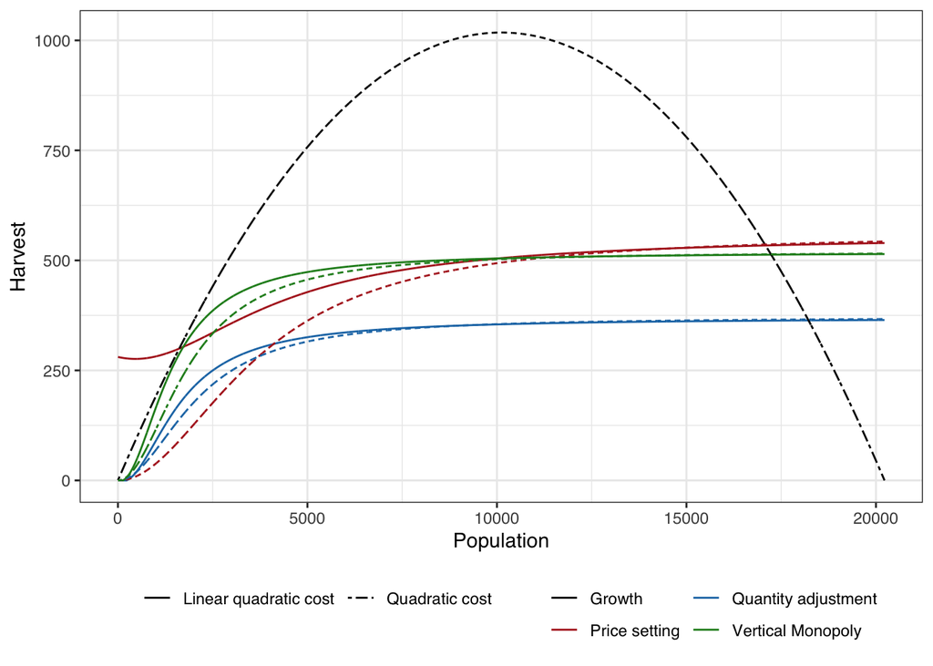

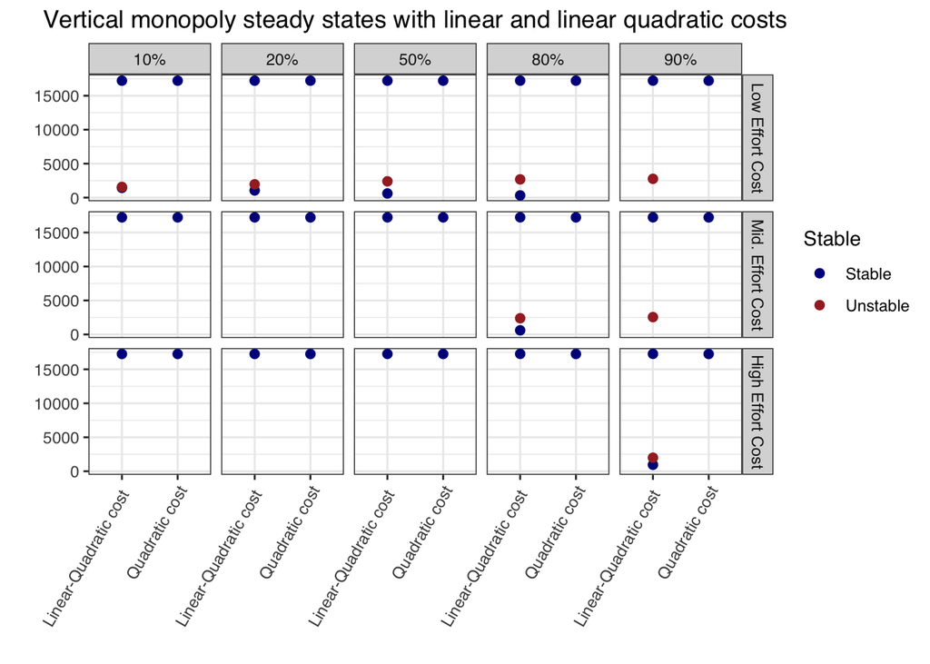

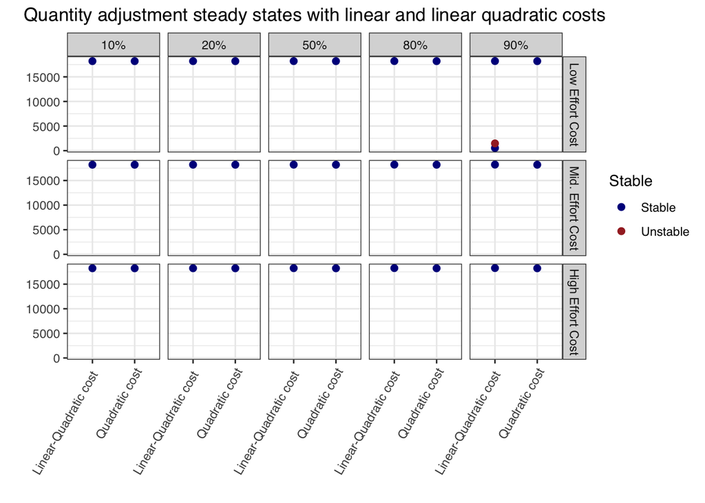

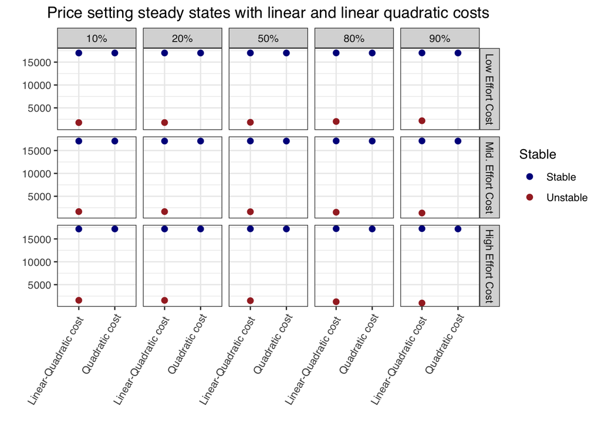